# HW2: Анализ проектов в Kickstarter

enpetrova_3

24/12/2020

У нас есть данные о проектах с платформы Kickstarter. На основе них мы будем стараться предсказать будет наш собственный проект успешным, то есть доберёт свою поставленную сумму. Допустим, я хочу основать свой проект, но еще не знаю какую категорию выбрать. Основываясь на данных введём новые переменные duration (длительность действия проекта до дедлайна), sum_day (отношение целевого заработка на длительность проекта)

Так как я могу выбирать только название, категорию, страну и дедлайн составим несколько гипотез:

H01:“Успешность не зависит от категории” - если нет, посмотрим в каких категория самая большой процент успешных проектов H02:“Успешность не зависит от страны” - если нет, выберем страну для реализации проекта H03:“Успешность не зависит от длительности осуществления проекта” - если нет, посмторим медианную длительность  
H04:“Количество инвесторов не влияет на успешность проекта” - если нет, то посмотрим имеет ли он прямую зависимость и уберем эту переменную из дерева, т.к. нам нужно будет стараться просто максимизировать этот показатель и для анализа именно своего проекта он мало чего даёт, ведь мы не можем точно повлиять на эту величину.

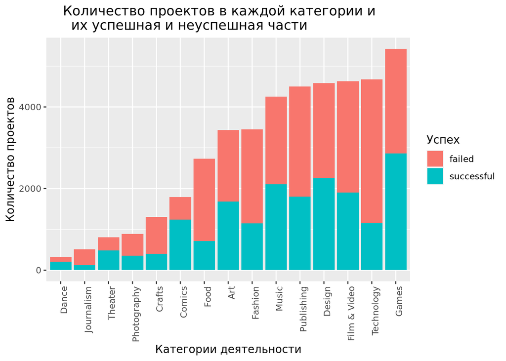

### H01: “Успешность не зависит от категории”

```
##
##  Asymptotic General Independence Test
##
## data:  state by
##   main_category (Art, Comics, Crafts, Dance, Design, Fashion, Film & Video, Food, Games, Journalism, Music, Photography, Publishing, Technology, Theater)
## maxT = 26.003, p-value < 0.00000000000000022
## alternative hypothesis: two.sided
```

```
##
##  Pearson's Chi-squared test
##
## data:  kickstarter$state and kickstarter$main_category
## X-squared = 2331, df = 14, p-value < 0.00000000000000022
```

Гипотеза отклоняется. Видим, что p-value очень маленький, значит категория всё-таки влияет на успех Теперь выберем одну из самых вероятных на успех категорию

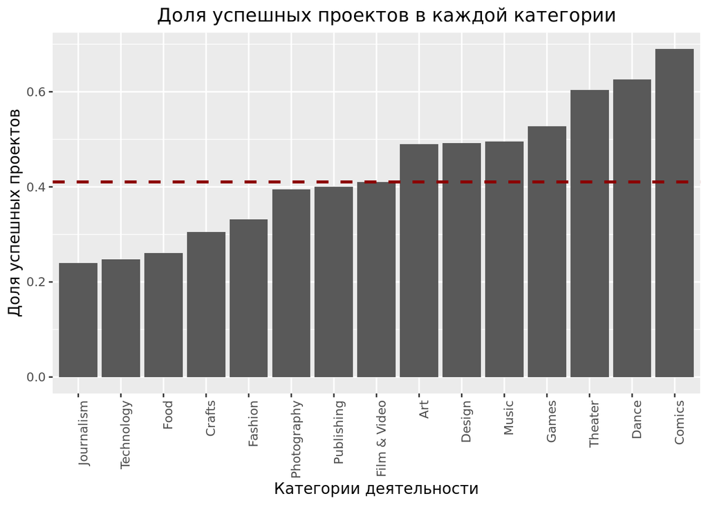

**Вывод:** Существуют категории, вероятность успеха которых 60% и больше, и такие, что вероятность будет меньше 30%. так что этот фактор важно учитывать при анализе. Основываясь только на вероятности успеха, не беря в расчет прибыль, которую мы получим (так как не обладаем данными об издержках), возбмем Comics за основную категорию деятельности

Но все равно можно проверить какую цель медианно ставят успешные проекты в своей категории

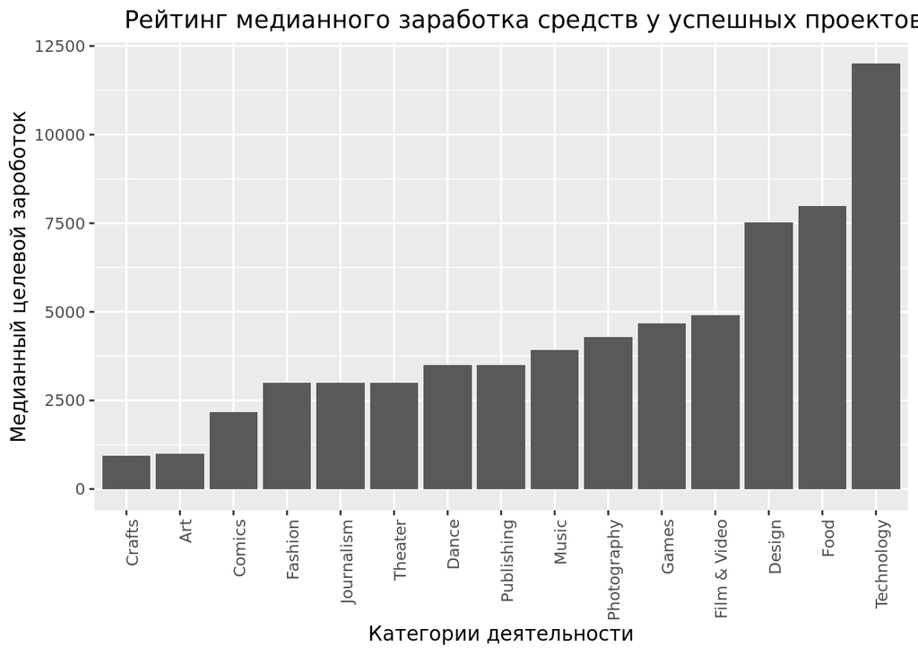

**Вывод:**: Самые вероятные на успех категории получают не самый большой заработок, что логично ведь риск должен стоить своих денег.

### H02: “Успешность не зависит от страны”

```
##
##  Asymptotic General Independence Test
##
## data:  state by
##   country (AT, AU, BE, CA, CH, DE, DK, ES, FR, GB, HK, IE, IT, LU, MX, NL, NO, NZ, SE, SG, US)
## maxT = 12.154, p-value < 0.00000000000000022
## alternative hypothesis: two.sided
```

```
##
##  Pearson's Chi-squared test
##
## data:  kick_comics$state and kick_comics$country
## X-squared = 44.912, df = 19, p-value = 0.0007051
```

Видим, что в обоих случаях p-value очень близок к 0, поэтому можно сделать вывод, что страна является достаточно одним из факторов успеха.

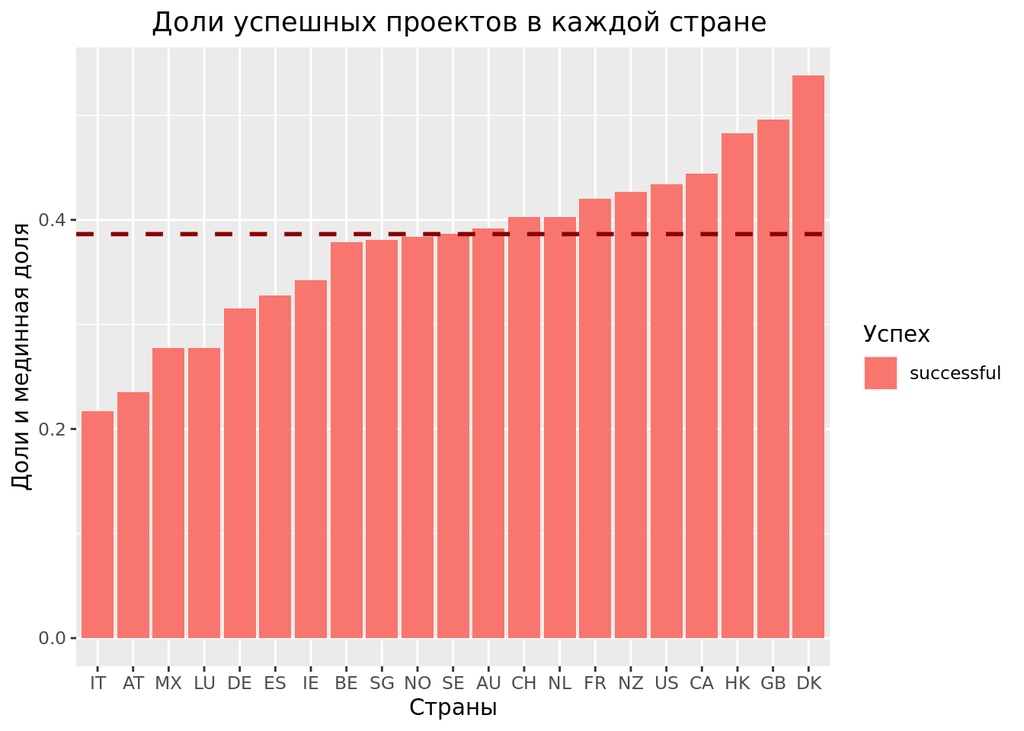

**Вывод:** Разброс в каждой стране от медианного значения существует, и вероятнее всего успешными проекты будут в Дании (DK), а наименее в Италии (IT).

Но теперь рассмотрим именно в нашей категории:

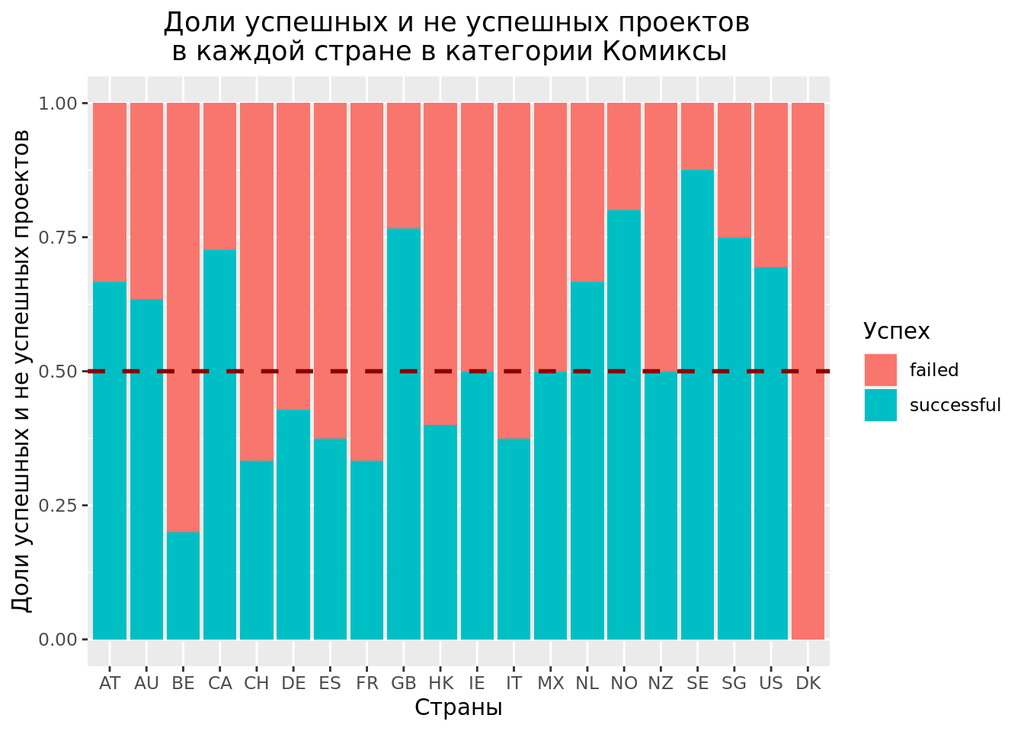

Видим, что несмотря на то, что страна в которой самый большой процент в общем Дания (DK) оказалась самой “неуспешной” для категории Comics. И для работы в этой категории лучше выбрать Швецию (SE), Норвегию (NO) или Великобританию (GB). Разброс от медиане именно в этой категории стал еще больше, так что можно предположить, что страна в определенных категориях имеет ещё большее влияние.

### H03: “Успешность не зависит от суммы получения в день”

```
##
##  Asymptotic General Independence Test
##
## data:  state by sum_day
## Z = 3.3447, p-value = 0.0008239
## alternative hypothesis: two.sided
```

Отношение целевого заработка на длительность осуществления проекта, как оказалось, также имеет влияние на успех.

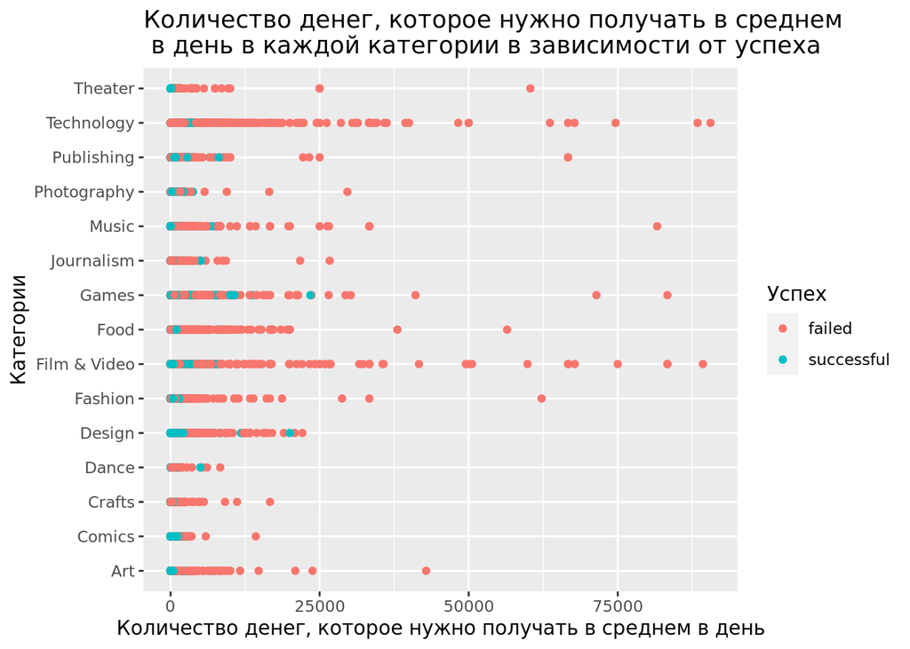

**Вывод:** Существует такое значение заработка в день, которое обеспечивает точный провал проекта и у каждой категории он свой. Её можно увиделть фильтруя значения sum_day.

### H04: “Количество инвесторов не влияет на успешность проекта”

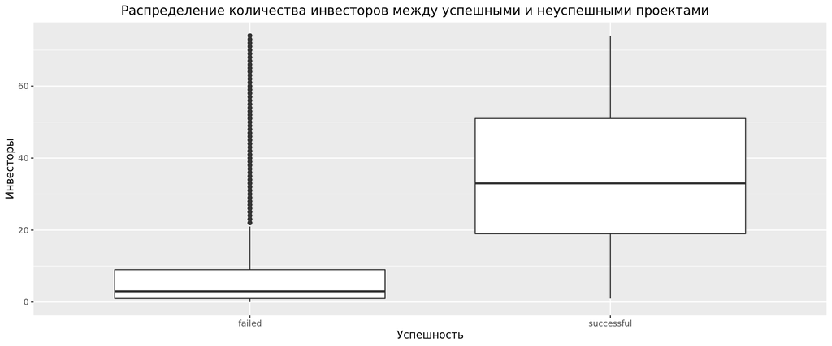

```
##
##  Welch Two Sample t-test
##
## data:  backers by state
## t = -35.818, df = 18474, p-value < 0.00000000000000022
## alternative hypothesis: true difference in means is not equal to 0
## 95 percent confidence interval:
##  -322.1174 -288.6918
## sample estimates:
##     mean in group failed mean in group successful
##                 14.57496                319.97954
```

### Строим дерево

Посторим дерево, основываясь на переменных, на которые мы можем в теории влиять. Возьмем cp=0,0001, чтобы потом выбрать самый оптимальный.

[figure not shown]

```
## [1] 0.7294046
```

```
## [1] 0.6472828
```

Получаем оргомное дерево, с точностью 73% на тренировочной и 65% на тестовой — слишком большая разница. Значит наша модель переобучена. Находим оптимальный cp с одним из наименьших значений кроссвалидации x-error.

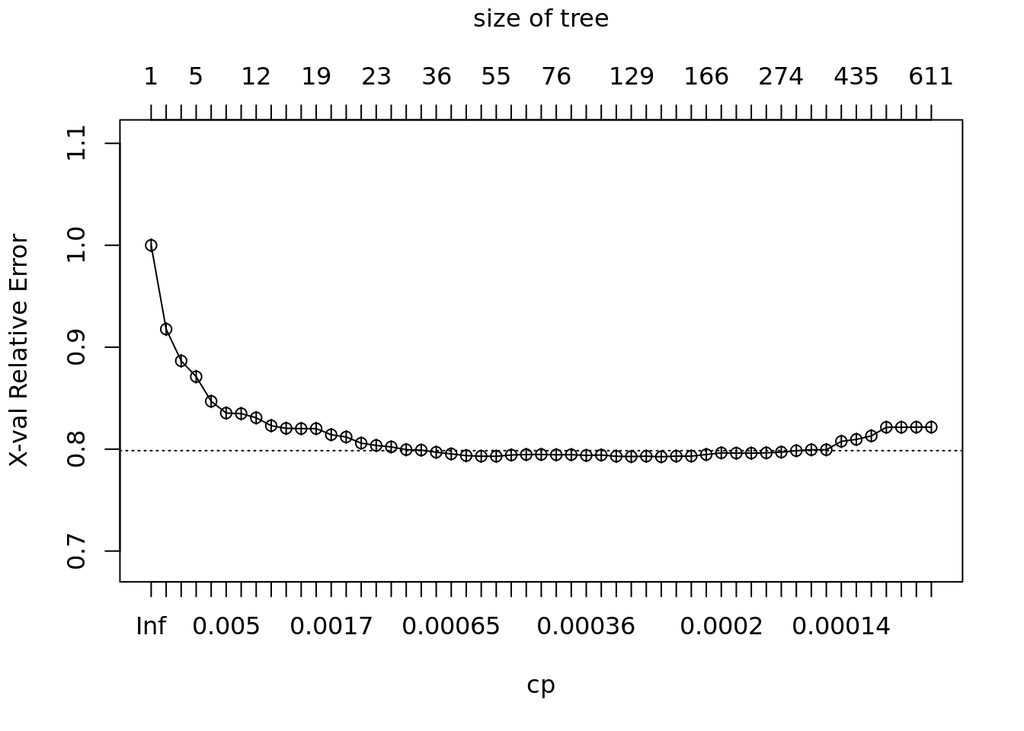

```
##
## Classification tree:
## rpart(formula = state ~ main_category + country + usd_goal_real +
##     sum_day + duration, data = kick_train, method = "class",
##     control = rpart.control(cp = 0.0001))
##
## Variables actually used in tree construction:
## [1] country       duration      main_category sum_day       usd_goal_real
##
## Root node error: 14701/34668 = 0.42405
##
## n= 34668
##
##            CP nsplit rel error  xerror      xstd
## 1  0.06224066      0   1.00000 1.00000 0.0062592
```

[output cut: 52 more lines]

Обрезаем дерево с cp=0.00088429, регулируя разницу точности для тренировончой и тестовой выборок.

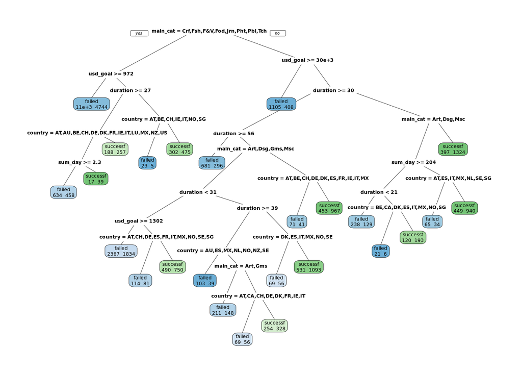

```
## [1] 0.6672436
```

```
## [1] 0.6457829
```

**В итоге:** Имеем дерево с 67% в тренировочной и 65% в итоговой выборках, что весьма приемлемо. Оно включает в себя переменные: категория, целевая сумма, страна, длительность деятельности, сумма в день. И по ней можно примерно спланировать и наметить какие величины лучше всего брать. То есть, выбрав категорию нужно определиться с суммой которую нужно поставить как цель, по дереву можно увидеть максимальное ориентировочное число, дальше длительность сбора денег, так же основываясь на категории, затем страна и так далее.

## Дэшборд

**Элемент 1:**

- тип: график
- Влияние категории на успешность проекта: является важным фактором при решении выбора категории или определения рисков для существующего проекта

**Элемент 2:**

- тип: график
- Влияние страны деятельности на успех проекта: является важным фактором при решении выбора страны или определения рисков для существующего проекта

**Элемент 3:**

- тип: дерево
- Дерево помогает провести анализ факторов для успеха проекта, выбора конкретных величин или/и корректировки существующих

**Элемент 4:**

- тип: числа
- Для примерной оценки результатов дерева